# PowerTransformation

### Power transformation (with sign)

As far as modelling and decomposition with pre-specified transformations are considered, we will use power transformations instead of Box-Cox transformations: the results are identical, but derivation and interpretation are easier.

We write $Y$ the variable in original scale and $y$ the transformed variable. the transformation and its reciprocal are defined by:

$$y=f(Y)=sign(Y) \lvert{Y}\rvert^{\lambda}$$

$$Y=f^{-1}(y)=sign(y) \lvert y\rvert^{1/ \lambda}$$

We define the operator $\oplus$ between two variables as follows:

$$A \oplus B = f^{-1}(f(A)+f(B))$$

When $\lambda = 1$, this is the usual sum.

When $f(Y)=\log{Y}, f^{-1}(y)=e^y$, $A \oplus B = A \times B$

When $\lambda=0.5$, $A \oplus B= sign(c) c^2$ where $c=sign(A)\sqrt{\lvert A \rvert}+ sign(B)\sqrt{\lvert B \rvert}$.

If we omit the signs, $A \oplus B= {\left(\sqrt A + \sqrt B \right)}^2$

We define the same way the operator $\ominus$ between two variables as follows:

$$A \ominus B = f^{-1}(f(A)-f(B))$$

### Seasonal adjustment

We consider now the decomposition computed on the transformed model

$$y = sa + s$$

As usual, if the log transformation has been applied, the decomposition in the original scale becomes

$$Y = SA \oplus S = e^{sa}*e^s=SA*S$$

After a square root transformation, we have (we suppose to simplify the notations that $sa \gt 0$ and $sa+s\gt 0$):

$$Y = SA \oplus S = \left(sa + s \right)^2 = SA + \lvert S \rvert + 2 sign(s) \sqrt{\lvert SA \times S \rvert }$$

$$= SA + S +2 \sqrt{S*SA} \quad ,S \ge 0$$

$$= SA - (S + 2 \sqrt{-S*SA}) \quad ,S \lt 0$$

We can define in a similar way $sa = y - s$ , $t=sa-i$ …

#### Example

##### Modelling using sqrt transformation

```r
library(rjdhf)
y<-c(750,9970,9000,8620,8630,8360,1010,790,9730,9120,8500,8970,8250,1040,850,10360,10380,11130,
     13050,12250,1580,940,13640,14760,15660,17390,17810,8040,3150,22590,24400,30000,30720,36700,
     21110,9420,39990,37250,34920,32990,23220,13140,6020,19060,33040,28850,26930,24090,11350,5780,
     25170,21800,20530,18290,16930,6660,4530,20930,18540,16570,15470,14980,5070,2970,17920,14670)

lam <- 1/2
z <- y^lam
cleaning <- rjdhf::fractionalAirlineEstimation(z,
                                               period=7,
                                               outliers = c("ao","ls","wo"),
                                               criticalValue = 5)

tval_b <- cleaning$model$b/sqrt(diag(cleaning$model$bcov))
data.frame(cleaning$model$variables,tval_b)
```

```
##   cleaning.model.variables    tval_b
## 1                    WO.44 -5.784616
```

```r
#
```

##### Decomposition of the linearized series

```r
y_clean <- cleaning$model$linearized
c <- rjdhf::fractionalAirlineDecomposition(y_clean, period=7)

all<-data.frame(y=c$decomp$y, t=c$decomp$t, sa=c$decomp$sa, s=c$decomp$s, i=c$decomp$i)
print(all)
```

```
##            y         t        sa         s           i
## 1   27.38613  76.76261  77.00081 -49.61468  0.23820170
## 2   99.84989  76.55217  76.92602  22.92387  0.37384746
## 3   94.86833  75.98358  75.78531  19.08302 -0.19827598
## 4   92.84396  75.34546  75.58264  17.26131  0.23718437
## 5   92.89779  75.00887  74.20361  18.69418 -0.80525856
## 6   91.43304  75.35873  75.41881  16.01422  0.06008200
## 7   31.78050  76.34275  75.83074 -44.05025 -0.51200910
## 8   28.10694  77.02498  78.75785 -50.65091  1.73287200
## 9   98.64076  76.58561  76.13647  22.50429 -0.44913821
## 10  95.49869  75.59089  76.10804  19.39065  0.51715528
## 11  92.19544  74.75060  74.08799  18.10746 -0.66261182
## 12  94.71008  74.46446  74.42221  20.28788 -0.04225411
## 13  90.82951  75.22214  74.13741  16.69210 -1.08472366
## 14  32.24903  77.76491  76.59109 -44.34206 -1.17381724
```

[output cut: 52 more lines]

###### Back transformed series

```r
allc<-sign(all)*abs(all)^(1/lam)
print(allc)
```

```
##           y         t        sa          s             i
## 1    750.00  5892.498  5929.124 -2461.6165   0.056740052
## 2   9970.00  5860.234  5917.612   525.5039   0.139761921
## 3   9000.00  5773.505  5743.413   364.1617  -0.039313364
## 4   8620.00  5676.938  5712.736   297.9528   0.056256426
## 5   8630.00  5626.330  5506.176   349.4725  -0.648441347
## 6   8360.00  5678.938  5687.997   256.4553   0.003609846
## 7   1010.00  5828.216  5750.302 -1940.4242  -0.262153320
## 8    790.00  5932.848  6202.799 -2565.5150   3.002845371
## 9   9730.00  5865.356  5796.763   506.4430  -0.201725136
## 10  9120.00  5713.982  5792.434   375.9972   0.267449588
## 11  8500.00  5587.652  5489.030   327.8799  -0.439054426
## 12  8970.00  5544.956  5538.665   411.5979  -0.001785410
## 13  8250.00  5658.370  5496.356   278.6261  -1.176625420
## 14  1040.00  6047.381  5866.196 -1966.2185  -1.377846916
```

[output cut: 52 more lines]

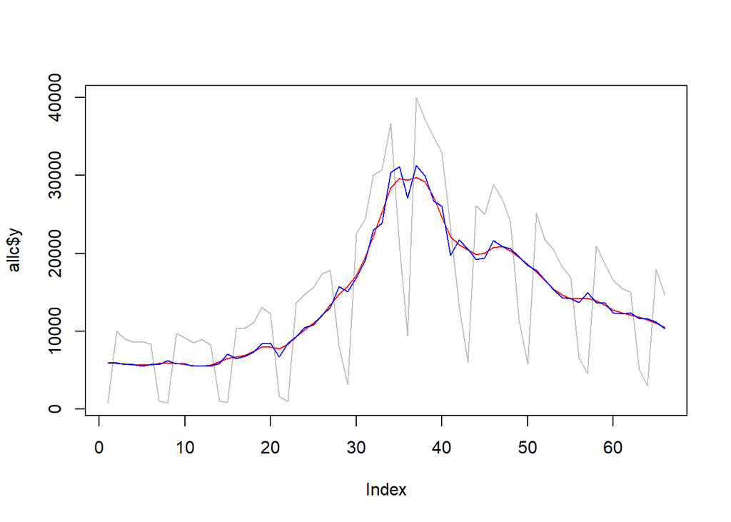

```r
plot(allc$y, type='l', col="gray")
lines(allc$t, col="red" )
lines(allc$sa, col="blue" )
```

##### Check constraints

```r
plus<-function(A,B, lambda){
  a<-sign(A)*abs(A)^lambda
  b<-sign(B)*abs(B)^lambda
  c<-a+b
  return (sign(c)*abs(c)^(1/lambda))
}

minus<-function(A,B, lambda){
  a<-sign(A)*abs(A)^lambda
  b<-sign(B)*abs(B)^lambda
  c<-a-b
  return (sign(c)*abs(c)^(1/lambda))
}

# Y = S + SA
cat("y=s+sa\n")
```

```
## y=s+sa
```

```r
summary(allc$y-plus(allc$sa, allc$s, lam))
```

```
##       Min.    1st Qu.     Median       Mean    3rd Qu.       Max.
## -3.638e-12  0.000e+00  0.000e+00 -3.411e-13  0.000e+00  4.547e-13
```

```r
#SA = Y - SA
cat("\nsa=y-s\n")
```

```
##
## sa=y-s
```

```r
summary(allc$sa-minus(allc$y, allc$s, lam))
```

```
##    Min. 1st Qu.  Median    Mean 3rd Qu.    Max.
##       0       0       0       0       0       0
```

```r
#T = SA - I
cat("\nt=sa-i\n")
```

```
##
## t=sa-i
```

```r
summary(allc$t-minus(allc$sa, allc$i, lam))
```

```
##      Min.   1st Qu.    Median      Mean   3rd Qu.      Max.
## 1.819e-12 1.826e-10 7.021e-10 8.268e-10 1.484e-09 2.039e-09
```

```r
cat("aggregation on 7 periods")
```

```
## aggregation on 7 periods
```

```r
rowsum(allc, 1+floor((0:(length(y)-1))/7))
```

```
##           y         t        sa         s            i
## 1   46340.0  40336.66  40247.36 -2608.494  -0.69353979
## 2   46400.0  40350.55  40182.24 -2631.189   0.07325765
## 3   59600.0  51122.28  51139.32 -2658.559 -15.33866551
## 4   88240.0  79025.50  79801.00 -2937.348  13.67574334
## 5  168670.0 157970.89 159366.47 -3475.293  27.22716984
## 6  190930.0 183425.99 182763.93 -3639.770 -64.33248933
## 7  148390.4 141776.50 141818.75 -3497.929   0.31516167
## 8  115160.0 111195.33 110386.18 -3091.591  -5.42508462
## 9   96090.0  90314.74  90768.13 -2578.198   8.33259568
## 10  35560.0  32955.19  33087.82 -1652.487   0.36629870
```